# probability_Distributions--their_stories

## Probability distributions and their stories

(c) 2017 Justin Bois. This work is licensed under a [Creative Commons Attribution License CC-BY 4.0](https://creativecommons.org/licenses/by/4.0/). All code contained herein is licensed under an [MIT license](https://opensource.org/licenses/MIT).

```python
import numpy as np
import scipy.stats as stats

import matplotlib.pyplot as plt
%matplotlib inline
```

Because this tutorial consists mainly of a list of probability distributions and their stories and properties, it is useful to have a little index of them up front.

- Discrete distributions
  - Bernoulli distribution
  - Geometric distribution
  - Negative Binomial distribution
  - Binomial distribution
  - Poisson distribution
  - Hypergeometric distribution
- Continuous distributions
  - Uniform distribution
  - Gaussian (a.k.a. Normal) distribution
  - Log-Normal distribution
  - Von Mises distribution
  - Chi-square distribution
  - Student-t/Cauchy distribution
  - Exponential distribution
  - Gamma distribution
  - Weibull distribution
  - Beta distribution
- Discrete multivariate distributions
  - Multinomial distribution
- Continuous multivariate distributions
  - Multivariate Gaussian distribution
  - Dirichlet distribution

### Motivation

We have talked about the three levels of building a model in the biological sciences.

- **Cartoon model**: A cartoon or verbal phenomenological description of the system of interest.
- **Mathematical model**: A mathematization of a cartoon model. This gives quantitative predictions on how a biological system should behave.
- **Statistical model**: A description of what we expect from an experiment, given our mathematical model. In the Bayesian context, this is specification of the likelihood and prior.

We have talked briefly about specifying priors and will discuss it in more depth in the next lecture.

Specifying the likelihood amounts to choosing a probability distribution that describes how the data will look under your model. In many cases, you need to derive the likelihood (or even numerically compute it when it cannot be written in closed form). In many practical cases, though, the choice of likelihood is among standard probability distributions. These distributions all have **stories** associated with them.

Importantly, *if your data and model match the story of a distribution, you know that this is the distribution to choose for your likelihood.*

## Review of probability distributions

Before we begin talking about distributions, let's remind ourselves what probability distributions are. We cut some corners in our definitions here, but these definitions are functional for most of our data analysis purposes.

A **probability mass function** (PMF), $f(x)$, describes the probability of a discrete variable obtaining value $x$. The variable $x$ takes on discrete values, so the **normalization condition** is

\begin{align} \sum_x f(x) = 1. \end{align}

A **probability density function** (PDF), which we shall call $f(x)$, is defined such that the probability that a continuous variable $x$ is $a \le x \le b$ is

\begin{align} \int_a^b \mathrm{d}x\,f(x). \end{align}

A **cumulative distribution function** (CDF), denoted $F(x)$ is defined such that $F(x)$ is the probability that a variable $X$ is less than or equal to $x$. For a discrete distribution

\begin{align} F(k) = \sum_{k'=k_\mathrm{min}}^k f(k'), \end{align}

and for a continuous distribution,

\begin{align} F(x) = \int_{-\infty}^x \mathrm{d}x'\,f(x'). \end{align}

If a probability mass or density function depends on parameters, say $n$ and $p$, we write it as $f(x;n, p)$. Note that we are using $f$ and semicolons for the PMF and PDF, where we have been writing expressions using $P$ and $|$ in our discussions of Bayes theorems. There does not seem to be consensus on the best notation. I am using $f$ here to designate that these are specific distributions with a parametrization outside the context of a specific inference problem, and convert to $P$ in the context of such a problem.

### Moments

Probability distributions **moments**. The way they are defined can vary, but we will define the $n$th moment computed from a PMF as

\begin{align} \left\langle x^n \right\rangle = \sum_i x_i^n f(x_i), \end{align}

and computed from a PDF as

\begin{align} \left\langle x^n \right\rangle = \int \mathrm{d}x\, x^n f(x). \end{align}

These moments are often used to compute summary statistics.

\begin{align} \text{mean} &= \langle x \rangle \\[1em] \text{variance} &= \left\langle x^2 \right\rangle - \langle x \rangle^2 = \left\langle(x - \langle x \rangle)^2 \right\rangle \\[1em] \text{skew} &= \frac{\left\langle(x - \langle x \rangle)^3 \right\rangle} {\left\langle(x - \langle x \rangle)^2 \right\rangle^{\frac{3}{2}}} \\[1em] \end{align}

I present PMF/PDF and CDF for distributions below. I mostly show univariate forms. I omit the moments, though they can be easily looked up, for example on Wikipedia.

### Sampling

Given that we know a probability distribution, we can take *samples* out of it. This means that we can randomly draw numbers and the probability that we draw a certain number $x$ is proportional to the PMF or PDF, $f(x)$. As we will soon discover in the course, sampling out of a distribution is often easier than computing the distribution over a range of values because many of those values are zero.

## Distributions and their stories

In what follows, I will present some commonly used probability distributions and their associated stories. For each distribution, I will give the name of the distribution, its story, its parameters, a biological example that follows this distribution where applicable, and an expressions for the PDF or PMF. I omit the CDF because CDFs are often expressed as special functions, such as regularized incomplete beta functions or error functions. They can also be easily looked up. We mainly use them for comparing ECDFs in plots, and we can use the `scipy.stats` module to just compute them.

## Discrete distributions

### Bernoulli distribution

- **Story.** A single trial with either a success (`k = True`) or failure (`k=False`) is performed. Such a trial is called a *Bernoulli trial*. The Bernoulli distribution defines the probability of getting each outcome.
- **Parameter.** The Bernoulli distribution is parametrized by a single value, $p$, the probability that the trial is successful. These trials are called *Bernoulli trials*.
- **Example.**

  > Check to see if a given bacterium is competent, given that it has probability $p$ of being competent.
- **Probability mass function.**

\begin{align} f(k;p) = \left\{ \begin{array}{ccc} 1-p & & k = 0 \\[0.5em] p & & k = 1 \\[0.5em] 0 & & \text{otherwise.} \end{array} \right. \end{align}

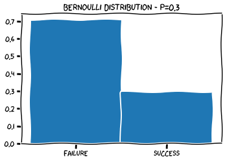

```python
x = stats.bernoulli.rvs(0.3,size=1000)
with plt.xkcd():
    plt.hist(x, bins=[0,1,2],density=True, align='left')
    plt.xticks([0,1], ('Failure', 'Success'))
    plt.title('Bernoulli Distribution - p=0.3')
```

### Geometric distribution

- **Story.** We perform a series of Bernoulli trials until we get a success. We have $k$ failures before the success.
- **Parameter.** The Geometric distribution is parametrized by a single value, $p$, the probability that the Bernoulli trial is successful.
- **Example.**

  > Consider actin polymerization. At each time step, an actin monomer may add to the filament ("failure"), or an actin monomer may fall off ("success") with (usually very low) probability $p$. The length of actin filaments are Geometrically distributed.
- **Probability mass function.**

\begin{align} f(k;p) = (1-p)^k p. \end{align}

- **Notes.** The Geometric distribution is only defined for non-negative integer $k$.

[figure not shown]

```python
gm1 = stats.geom(0.2)
gm2 = stats.geom(0.5)
gm3 = stats.geom(0.7)
k = np.arange(10)
with plt.xkcd():
    plt.figure(figsize=(7,4))
    plt.bar(k-0.2, gm1.pmf(k), width=.2, color='b')
    plt.bar(k, gm2.pmf(k), width=.2, color='r')
    plt.bar(k+0.2, gm3.pmf(k), width=.2, color='g')
    plt.legend(['p=0.2', 'p=0.5', 'p=0.7'])
    plt.xlim(0,10)
    plt.title('Geometric distribution - no of failures before 1st success')
```

### Negative Binomial distribution

- **Story.** We perform a series of Bernoulli trials until we get $r$ successes. The number of failures, $k$, before we get $r$ successes is Negative Binomially distributed.
- **Parameters.** There are two parameters: the probability $p$ of success for each Bernoulli trial, and the desired number of successes, $r$.
- **Example.**

  > Bursty gene expression can give mRNA count distributions that are Negative Binomially distributed. Here, "success" is that a burst in gene expression stops. So, the parameter $p$ is related to the length of a burst in expression (lower $p$ means a longer burst). The parameter $r$ is related to the frequency of the bursts. If multiple bursts are possible within the lifetime of mRNA, then $r > 1$. Then, the number of "failures" is the number of mRNA transcripts that are made in the characteristic lifetime of mRNA.
- **Probability mass function.**

\begin{align} f(k;r,p) = \begin{pmatrix} k+r-1 \\ r-1 \end{pmatrix} p^r (1-p)^k. \end{align}

Generally speaking, $r$ need not be an integer, so we may write the PMF as

\begin{align} f(k;r, p) = \frac{\Gamma(k+r)}{\Gamma(r) k!}\,p^r(1-p)^k. \end{align}

> *PyMC3 defines the distribution in terms of $\mu$ and $\alpha$, with the change of variables being $\alpha = r$ and $\mu = r(1-p)/p$.

**Notes.** If $r = 1$, this distribution reduces to the Geometric distribution.

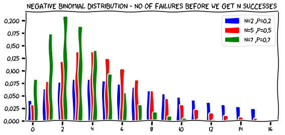

```python
nbm1 = stats.nbinom(2,0.2)
nbm2 = stats.nbinom(5,0.5)
nbm3 = stats.nbinom(7,0.7)
k = np.arange(16)
with plt.xkcd():
    plt.figure(figsize=(9,4))
    plt.bar(k-0.2, nbm1.pmf(k), width=.2, color='b')
    plt.bar(k, nbm2.pmf(k), width=.2, color='r')
    plt.bar(k+0.2, nbm3.pmf(k), width=.2, color='g')
    plt.legend(['n=2 ,p=0.2', 'n=5 ,p=0.5', 'n=7 ,p=0.7'])
    plt.xlim(-0.5,16.5)
    plt.xticks( np.arange(0,17,2))
    plt.title('Negative Binomial distribution - no of failures before we get n successes')
```

### Binomial distribution

- **Story.** We perform $n$ Bernoulli trials with probability $p$ of success. The number of successes, $k$, is binomially distributed.
- **Parameters.** There are two parameters: the probability $p$ of success for each Bernoulli trial, and the number of trials, $n$.
- **Example.**

  > Distribution of plasmids between daughter cells in cell division. Each of the $n$ plasmids as a chance $p$ of being in daughter cell 1 ("success"). The number of plasmids, $k$, in daughter cell 1 is binomially distributed.
- **Probability mass function.**

\begin{align} f(k;n,p) = \begin{pmatrix} n \\ k \end{pmatrix} p^k (1-p)^{n-k}. \end{align}

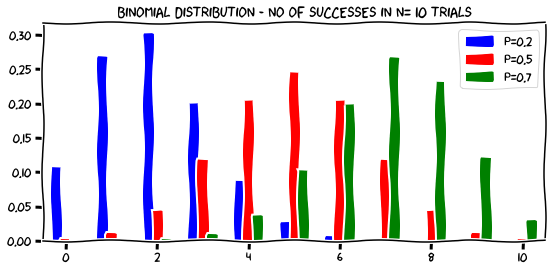

```python
nbm1 = stats.binom(10,0.2)
nbm2 = stats.binom(10,0.5)
nbm3 = stats.binom(10,0.7)
k = np.arange(16)
with plt.xkcd():
    plt.figure(figsize=(9,4))
    plt.bar(k-0.2, nbm1.pmf(k), width=.2, color='b')
    plt.bar(k, nbm2.pmf(k), width=.2, color='r')
    plt.bar(k+0.2, nbm3.pmf(k), width=.2, color='g')
    plt.legend(['p=0.2', 'p=0.5', 'p=0.7'])
    plt.xlim(-0.5,10.5)
    plt.xticks( np.arange(0,12,2))
    plt.title('Binomial distribution - No of successes in N= 10 trials')
```

### Poisson distribution

- **Story.** Rare events occur with a rate $\lambda$ per unit time. There is no "memory" of previous events; i.e., that rate is independent of time. A process that generates such events is called a *Poisson process*. The occurrence of a rare event in this context is referred to as an *arrival*. The number $k$ of arrivals in unit time is Poisson distributed.
- **Parameter.** The single parameter is the rate $\lambda$ of the rare events occurring.
- **Example.**

  > The number of mutations in a strand of DNA per unit length (since mutations are rare) are Poisson distributed.
- **Probability mass function.** \begin{align} f(k;\lambda) = \frac{\lambda^k}{k!}\,\mathrm{e}^{-\lambda}. \end{align}
- **Notes.** The Poisson distribution is a limit of the binomial distribution in which the number of trials goes to infinity, but the expected number of successes, $np$, stays fixed. Thus, \begin{align} f_\mathrm{Poisson}(k;\lambda) \approx f_\mathrm{Binomial}(k;n, p), \end{align} with $\lambda = np$. Considering the biological example of mutations, this is binomially distributed: There are $n$ bases, each with a probability $p$ of mutation, so the number of mutations, $k$ is binomially distributed. Since $p$ is small, it is approximately Poisson distributed.

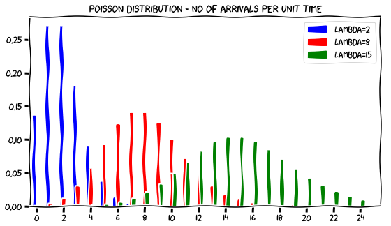

```python
ps1 = stats.poisson(2)
ps2 = stats.poisson(8)
ps3 = stats.poisson(15)
k = np.arange(25)
with plt.xkcd():
    plt.figure(figsize=(9,5))
    plt.bar(k-0.2, ps1.pmf(k), width=.2, color='b')
    plt.bar(k, ps2.pmf(k), width=.2, color='r')
    plt.bar(k+0.2, ps3.pmf(k), width=.2, color='g')
    plt.legend(['lambda=2', 'lambda=8', 'lambda=15'])
    plt.xlim(-0.5,25.5)
    plt.xticks(np.arange(0,25,2))
    plt.title('Poisson distribution - no of arrivals per unit time')
```

### Hypergeometric distribution

- **Story.** Consider an urn with $w$ white balls and $b$ black balls. Draw $n$ balls from this urn *without replacement*. The number white balls drawn, $k$, is Hypergeometrically distributed.
- **Parameters.** There are three parameters: the number of draws $n$, the number of white balls $w$, and the number of black balls $b$.
- **Example.**

  > There are $N$ finches on an island, and $n_t$ of them are tagged. You capture $n$ finches. The number of tagged finches $k$ is Hypergeometrically distributed, $f(k;n_t, N-n_t, n)$, as defined below.
- **Probability mass function.**

\begin{align} f(k;w, b, n) = \frac{\begin{pmatrix}w\\k\end{pmatrix}\begin{pmatrix}b\\n-k\end{pmatrix}} {\begin{pmatrix}w+b\\n\end{pmatrix}}. \end{align} Alternatively, if we define $N = w + b$, we could write \begin{align} f(k;N, w, n) = \frac{\begin{pmatrix}w\\k\end{pmatrix}\begin{pmatrix}N-w\\n-k\end{pmatrix}} {\begin{pmatrix}N\\n\end{pmatrix}}. \end{align} This is how it is [defined in the `scipy.stats` module](https://docs.scipy.org/doc/scipy-0.19.1/reference/generated/scipy.stats.hypergeom.html). In general, because distributions have different equivalent representations, it is important to check the documentation to make sure you are using the function correctly.

> This distribution is analogous to the `Binomial` distribution, except that the Binomial distribution describes draws from an urn *with replacement*. In the analogy, $p = w/(w+b)$.

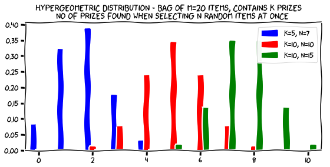

```python
hpg1 = stats.hypergeom(20,7,5)
hpg2 = stats.hypergeom(20,10,10)
hpg3 = stats.hypergeom(20,15,10)
k = np.arange(111)
with plt.xkcd():
    plt.figure(figsize=(9,4))
    plt.bar(k-0.2, hpg1.pmf(k), width=.2, color='b')
    plt.bar(k, hpg2.pmf(k), width=.2, color='r')
    plt.bar(k+0.2, hpg3.pmf(k), width=.2, color='g')
    plt.legend(['k=5, N=7', 'k=10, N=10', 'k=10, N=15'])
    plt.xlim(-0.5,10.5)
    plt.xticks( np.arange(0,12,2))
    plt.suptitle('hypergeometric distribution - bag of M=20 items, contains k prizes', y=0.99)
    plt.title('No of prizes found when selecting N random items at once ')
```

## Continuous distributions

### Uniform distribution

- **Story.** Any outcome in a given range has equal probability.
- **Parameters.** The Uniform distribution is not defined on an infinite or semi-infinite domain, so bounds, $x_\mathrm{min}$ and $x_\mathrm{max}$ are necessary parameters.
- **Example.**

  > Anything in which all possibilities are equally likely.
- **Probability density function.**

\begin{align} f(x;x_\mathrm{min}, x_\mathrm{max}) = \left\{ \begin{array}{ccc} \frac{1}{x_\mathrm{max} - x_\mathrm{min}} & & x_\mathrm{min} \le x \le x_\mathrm{max} \\[0.5em] 0 & & \text{otherwise.} \end{array} \right. \end{align}

### Gaussian, a.k.a. Normal, distribution

- **Story.** Any quantity that emerges as the sum of a large number of subprocesses tends to be Gaussian distributed provided none of the subprocesses is very broadly distributed.
- **Parameters.** The Gaussian distribution has two parameters, the mean $\mu$, which determines the location of its peak, and the standard deviation $\sigma$, which is strictly positive (the $\sigma\to 0$ limit defines a Dirac delta function) and determines the width of the peak.
- **Example.**

  > We measure the length of many *C. elegans* eggs. The lengths are Gaussian distributed.
- **Probability density function.**

\begin{align} f(x;\mu, \sigma) = \frac{1}{\sqrt{2\pi \sigma^2}}\,\mathrm{e}^{-(x-\mu)^2/2\sigma^2}. \end{align}

- **Notes.** This is a limiting distribution in the sense of the central limit theorem, but also in that many distributions have a Gaussian distribution as a limit. This is seen by formally taking limits of, e.g., the Gamma, Student-t, Binomial distributions, which allows direct comparison of parameters.

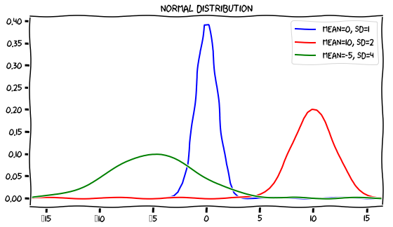

```python
norm1 = stats.norm(0,1)
norm2 = stats.norm(10,2)
norm3 = stats.norm(-5,4)
k = np.linspace(-20, 20, 100)
with plt.xkcd():
    plt.figure(figsize=(9,5))
    plt.plot(k, norm1.pdf(k), color='b')
    plt.plot(k, norm2.pdf(k), color='r')
    plt.plot(k, norm3.pdf(k), color='g')
    plt.legend(['mean=0, SD=1', 'mean=10, SD=2', 'mean=-5, SD=4'])
    plt.xlim(-16.5,16.5)
    plt.title('Normal distribution')
```

### Log-Normal distribution

- **Story.** If $\ln x$ is Gaussian distributed, $x$ is Log-Normally distributed.
- **Parameters.** As for a Gaussian, there are two parameters, the mean logarithm, $\ln \mu$, and the variance $\sigma^2$.
- **Example.**

  > A measure of fold change in gene expression can be Log-Normally distributed.
- **Probability density function.**

\begin{align} f(x;\mu, \sigma) = \frac{1}{x\sqrt{2\pi \sigma^2}}\,\mathrm{e}^{-(\ln x - \ln \mu)^2/2\sigma^2}. \end{align}

- **Notes.** The Log-Normal distribution in the `scipy.stats` module is defined in terms of $\mu$, not $\ln \mu$.

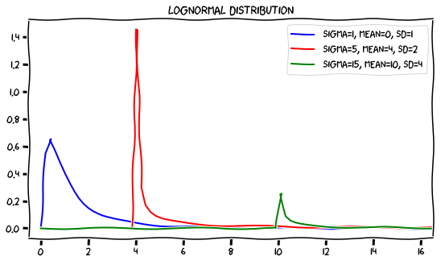

```python
lnrm1 = stats.lognorm(1,0,1)
lnrm2 = stats.lognorm(5,4,2)
lnrm3 = stats.lognorm(15,10,4)
k = np.linspace(0, 20, 100)
with plt.xkcd():
    plt.figure(figsize=(9,5))
    plt.plot(k, lnrm1.pdf(k), color='b')
    plt.plot(k, lnrm2.pdf(k), color='r')
    plt.plot(k, lnrm3.pdf(k), color='g')
    plt.legend(['sigma=1, mean=0, SD=1', 'sigma=5, mean=4, SD=2', 'sigma=15, mean=10, SD=4'])
    plt.xlim(-0.5,16.5)
    plt.title('LogNormal distribution')
```

### Von Mises distribution

  > Repeated measurements on a periodic domain, e.g., the location of an ingression along the azimuthal angle of a developing embryo.
- **Probability density function.**

\begin{align} f(\theta;\mu, \beta) = \frac{1}{2\pi I_0(\beta)}\,\mathrm{e}^{\beta \cos(\theta - \mu)}, \end{align}

where $I_0(\beta)$ is a modified Bessel function of the first kind.

- **Notes.** The CDF for the Von Mises distribution is ill-defined because values of $\theta$ differing by factors of $2\pi$ are equivalent.

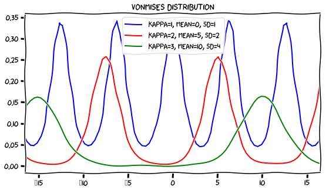

```python
vm1 = stats.vonmises(1,0,1)
vm2 = stats.vonmises(2,5,2)
vm3 = stats.vonmises(3,10,4)
k = np.linspace(-20, 20, 100)
with plt.xkcd():
    plt.figure(figsize=(9,5))
    plt.plot(k, vm1.pdf(k), color='b')
    plt.plot(k, vm2.pdf(k), color='r')
    plt.plot(k, vm3.pdf(k), color='g')
    plt.legend(['kappa=1, mean=0, SD=1', 'kappa=2, mean=5, SD=2', 'kappa=3, mean=10, SD=4'])
    plt.xlim(-16.5,16.5)
    plt.title('VonMises distribution')
```

### Chi-square distribution

- **Story.** If $X_1$, $X_2$, $\ldots$, $X_n$ are Gaussian distributed, $X_1^2 + X_2^2 + \cdots + X_n^2$ is $\chi^2$-distributed. See also the story of the Gamma distribution, below.
- **Parameters.** There is only one parameter, the degrees of freedom $n$.
- **Probability density function.** \begin{align} f(x;n) \equiv \chi^2_n(x;n) = \frac{1}{2^{n/2}\Gamma\left(\frac{n}{2}\right)}\, x^{\frac{n}{2}-1}\,\mathrm{e}^{-x/2}. \end{align}
- **Notes.** The Chi-square distribution is a special case of the Gamma distribution with $a = n/2$ and $r = 1/2$.

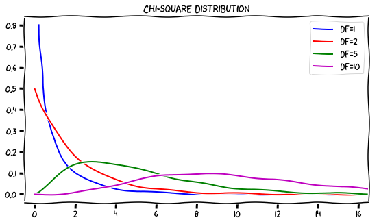

```python
chisq1 = stats.chi2(1)
chisq2 = stats.chi2(2)
chisq3 = stats.chi2(5)
chisq4 = stats.chi2(10)
k = np.linspace(0, 20, 100)
with plt.xkcd():
    plt.figure(figsize=(9,5))
    plt.plot(k, chisq1.pdf(k), color='b')
    plt.plot(k, chisq2.pdf(k), color='r')
    plt.plot(k, chisq3.pdf(k), color='g')
    plt.plot(k, chisq4.pdf(k), color='m')
    plt.legend(['df=1', 'df=2', 'df=5', 'df=10'])
    plt.xlim(-0.5,16.5)
    plt.title('Chi-square distribution')
```

### Student-t/Cauchy distribution

- **Story.** We get this distribution whenever we marginalize an unknown $\sigma$ out of a Gaussian distribution with a Jeffreys prior for $\sigma$.
- **Parameters.** The Student-t distribution is peaked, and its peak is located at $m$. The peak's width is dictated by parameter $s$. Finally, we define the "degrees of freedom" as $n$.
- **Example.**

  > The story says it all!
- **Probability density function.**

\begin{align} f(x;m, s, n) = \frac{\Gamma\left(\frac{n+1}{2}\right)}{\Gamma\left(\frac{n}{2}\right)\sqrt{\pi n s^2}}\, \left(1 + \frac{(x-m)^2}{ns^2}\right)^{-\frac{n+1}{2}}. \end{align}

Another parametrization, importantly the one used by PyMC3, defines $\mu = m$, $\nu = n$ and $\lambda = s^{-2}$, giving \begin{align} f(x;\mu, \lambda, \nu) = \frac{\Gamma\left(\frac{\nu+1}{2}\right)}{\Gamma\left(\frac{\nu}{2}\right)}\left(\frac{\lambda}{\pi \nu}\right)^{\frac{1}{2}}\, \left(1 + \frac{\lambda(x-\mu)^2}{\nu}\right)^{-\frac{\nu+1}{2}}. \end{align}

**Notes.** For $n\to \infty$, we get a Gaussian distribution. When $n = 1$, we get the **Cauchy distribution**, \begin{align} f(x;m, s) = \left[\pi s\left(1+ \left(\frac{x-m}{s}\right)^2\right)\right]^{-1}. \end{align} The Student-t distribution is very much like a Gaussian distribution, except with heavy tails. In the Cauchy limit, the tails are so heavy that the first moment does not exist.

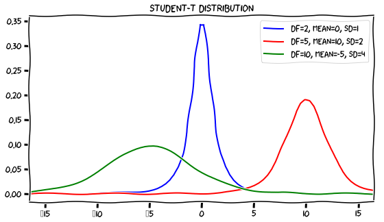

```python
t1 = stats.t(2,0,1)
t2 = stats.t(5,10,2)
t3 = stats.t(10,-5,4)
k = np.linspace(-20, 20, 100)
with plt.xkcd():
    plt.figure(figsize=(9,5))
    plt.plot(k, t1.pdf(k), color='b')
    plt.plot(k, t2.pdf(k), color='r')
    plt.plot(k, t3.pdf(k), color='g')
    plt.legend(['df=2, mean=0, SD=1', 'df=5, mean=10, SD=2', 'df=10, mean=-5, SD=4'])
    plt.xlim(-16.5,16.5)
    plt.title('student-t distribution')
```

### Exponential distribution

- **Story.** This is the waiting time for an arrival from a Poisson process. I.e., the inter-arrival time of a Poisson process is Exponentially distributed.
- **Parameter.** The single parameter is the average arrival *rate*, $r$. Alternatively, we can use $\tau=1/r$ as the parameter, in this case a characteristic arrival *time*.

**Example.**

> The time between conformational switches in a protein is Exponentially distributed (under simple mass action kinetics).

**Probability density function.** \begin{align} f(x;r) = r \mathrm{e}^{-rx}. \end{align}

Alternatively, we could parametrize it as

\begin{align} f(x;\tau) = \frac{1}{\tau}\, \mathrm{e}^{-x/\tau}. \end{align}

**Notes.** The Exponential distribution is the continuous analog of the Geometric distribution. The "rate" in the Exponential distribution is analogous to the probability of success of the Bernoulli trial. Note also that because they are uncorrelated, the amount of time between any two arrivals is independent of all other inter-arrival times.

Th implementation in the `scipy.stats` module also has a location parameter, which shifts the distribution left and right. For our purposes, you can ignore that parameter, but be aware that `scipy.stats` requires it.

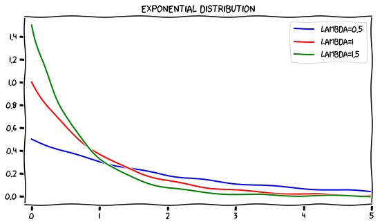

```python
exp1 = stats.expon(scale=1/.5)
exp2 = stats.expon(scale=1)
exp3 = stats.expon(scale=1/1.5)
k = np.linspace(0, 5, 100)
with plt.xkcd():
    plt.figure(figsize=(9,5))
    plt.plot(k, exp1.pdf(k), color='b')
    plt.plot(k, exp2.pdf(k), color='r')
    plt.plot(k, exp3.pdf(k), color='g')
    plt.legend(['lambda=0.5', 'lambda=1', 'lambda=1.5'])
    plt.xlim(-0.1,5)
    plt.title('Exponential distribution')
```

### Gamma distribution

- **Story.** The amount of time we have to wait for $a$ arrivals of a Poisson process. More concretely, if we have events, $X_1$, $X_2$, $\ldots$, $X_a$ that are exponentially distributed, $X_1 + X_2 + \cdots + X_a$ is Gamma distributed.
- **Parameters.** The number of arrivals, $a$, and the rate of arrivals, $r$.
- **Example.**

  > Any multistep process where each step happens at the same rate. This is common in molecular rearrangements, and we will use it in class to describe the nature of processes triggering microtubule catastrophe.
- **Probability density function.**

\begin{align} f(x;a, r) = \frac{1}{\Gamma(a)}\,\frac{(rx)^a}{x}\,\mathrm{e}^{-rx}, \end{align}

where $\Gamma(a)$ is the gamma function.

- **Notes.** The Gamma distribution is the continuous analog of the Negative Binomial distribution. The special case of $a = n/2$ and $r = 1/2$ is a Chi-square distribution.

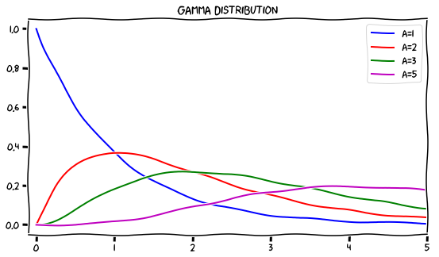

```python
gm1 = stats.gamma(a=1)
gm2 = stats.gamma(a=2)
gm3 = stats.gamma(a=3)
gm4 = stats.gamma(a=5)
k = np.linspace(0, 5, 100)
with plt.xkcd():
    plt.figure(figsize=(9,5))
    plt.plot(k, gm1.pdf(k), color='b')
    plt.plot(k, gm2.pdf(k), color='r')
    plt.plot(k, gm3.pdf(k), color='g')
    plt.plot(k, gm4.pdf(k), color='m')
    plt.legend(['a=1', 'a=2', 'a=3','a=5'])
    plt.xlim(-0.1,5)
    plt.title('Gamma distribution')
```

### Weibull distribution

- **Story.** Distribution of $x = y^\beta$ if $y$ is exponentially distributed. For $\beta > 1$, the longer we have waited, the more likely the event is to come, and vice versa for $\beta < 1$.
- **Parameters.** There are two parameters, both strictly positive: the shape parameter $\beta$, which dictates the shape of the curve, and the scale parameter $\tau$, which dictates the rate of arrivals of the event.
- **Example.**

  > *This is a model for aging. The longer an organism lives, the more likely it is to die.*
- **Probability density function.**

\begin{align} f(x;\tau, \beta) = \frac{\beta}{\tau}\left(\frac{x}{\tau}\right)^{\beta - 1}\, \mathrm{e}^{-(x/\tau)^\beta}. \end{align}

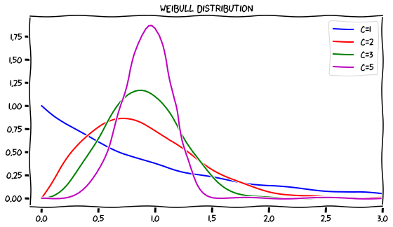

```python
wb1 = stats.weibull_min(c=1)
wb2 = stats.weibull_min(c=2)
wb3 = stats.weibull_min(c=3)
wb4 = stats.weibull_min(c=5)
k = np.linspace(0, 3, 100)
with plt.xkcd():
    plt.figure(figsize=(9,5))
    plt.plot(k, wb1.pdf(k), color='b')
    plt.plot(k, wb2.pdf(k), color='r')
    plt.plot(k, wb3.pdf(k), color='g')
    plt.plot(k, wb4.pdf(k), color='m')
    plt.legend(['c=1', 'c=2', 'c=3','c=5'])
    plt.xlim(-0.1,3)
    plt.title('Weibull distribution')
```

### Beta distribution

- **Story.** Say you wait for two multistep processes to happen. The individual steps of each process happen at the same rate, but the first multistep process requires $a$ steps and the second requires $b$ steps. The fraction of the total waiting time take by the first process is Beta distributed.
- **Parameters.** There are two parameters, both strictly positive: $a$ and $b$, defined in the above story.
- **Probability density function.** \begin{align} f(x;a, b) = \frac{x^{a-1}(1-x)^{b-1}}{B(a,b)}, \end{align} where \begin{align} B(a,b) = \frac{\Gamma(a)\,\Gamma(b)}{\Gamma(a + b)} \end{align} is the Beta function.
- **Notes.** The story of the Beta distribution is difficult to parse. Most importantly for our purposes, the Beta distribution allows us to put probabilities on unknown probabilities. It is only defined on $0\le x\le 1$, and $x$ here can be interpreted as a probability, say of a Bernoulli trial. We will use the Beta distribution as a conjugate prior to the Binomial distribution in coming lessons.

The special case where $a=b=1$ gives a Uniform distribution on the interval $0\le x\le 1$.

The case where $a = b = 0$ is not technically a probability distribution because the PDF cannot be normalized. Nonetheless, it can be used as an improper prior, and this prior is known a Haldane prior, names after biologist J. B. S. Haldane. The case where $a = b = 1/2$ is a Jeffreys prior, as we will see future lessons.

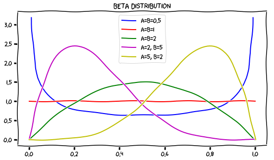

```python
bt1 = stats.beta(a=.5, b=.5)
bt2 = stats.beta(a=1, b=1)
bt3 = stats.beta(a=2, b=2)
bt4 = stats.beta(a=2, b=5)
bt5 = stats.beta(a=5, b=2)
k = np.linspace(0, 1, 100)
with plt.xkcd():
    plt.figure(figsize=(9,5))
    plt.plot(k, bt1.pdf(k), color='b')
    plt.plot(k, bt2.pdf(k), color='r')
    plt.plot(k, bt3.pdf(k), color='g')
    plt.plot(k, bt4.pdf(k), color='m')
    plt.plot(k, bt5.pdf(k), color='y')
    plt.legend(['a=b=0.5', 'a=b=1', 'a=b=2','a=2, b=5', 'a=5, b=2'])
    #plt.xlim(-0.1,1.1)
    plt.title('Beta distribution')
```

## Discrete multivariate distributions

So far, we have looked a univariate distributions, but we will consider multivariate distributions in class, and you will encounter them in your research. First, we consider a discrete multivariate distribution, the Multinomial.

### Multinomial distribution

- **Story.** This is a generalization of the Binomial distribution. Instead of a Bernoulli trial consisting of two outcomes, each trial has $k$ outcomes. The probability of getting $n_1$ of outcome 1, $n_2$ of outcome 2, ..., and $n_k$ of outcome $k$ out of a total of $n$ trials is Multinomially distributed.
- **Parameters.** $n$, the total number of trials, and $\mathbf{p} = \{p_1, p_2, \ldots p_k\}$, the probabilities of each outcome. Note that $\sum_i p_i = 1$ and there is a further restriction that $\sum_i n_i = n$.
- **Example.**

  > There are two alleles in a population, A and a. Each individual may have genotype AA, Aa, or aa. The probability distribution describing having $n_1$ AA individuals, $n_2$ Aa individuals, and $n_3$ aa individuals in a population of $n$ total individuals is Multinomially distributed.
- **Probability density function.** \begin{align} f(\mathbf{n};n, \mathbf{p}) = \frac{n!}{n_1!\,n_2!\cdots n_k!}\,p_1^{n_1}\,p_2^{n_2}\cdots p_k^{n_k}. \end{align}

## Continuous Multivariate distributions

### Multivariate Gaussian distribution

- **Story.** This is a generalization of the univariate Gaussian.
- **Parameters.** There is one vector-valued parameter, $\boldsymbol{\mu}$, and a matrix-valued parameter, $\mathsf{\Sigma}$, referred to respectively as the mean and covariance matrix. The covariance matrix is symmetric and strictly positive definite.
- **Example.**

  > Finch beaks are measured for beak depth and beak length. The resulting distribution of depths and length is Gaussian distributed. In this case, the Gaussian is bivariate, with $\mu = (\mu_\mathrm{d}, \mu_\mathrm{l})$ and \begin{align} \mathsf{\Sigma} = \begin{pmatrix} \sigma_\mathrm{d}^2 & \sigma_\mathrm{dl} \\ \sigma_\mathrm{dl} & \sigma_\mathrm{l}^2 \end{pmatrix}. \end{align}
- **Probability density function.** \begin{align} f(\mathbf{x};\boldsymbol{\mu}, \mathsf{\Sigma}) = \frac{1}{\sqrt{2\pi \det \mathsf{\Sigma}}}\,\mathrm{exp}\left[-\frac{1}{2}(\mathbf{x} - \boldsymbol{\mu})^T \cdot \mathsf{\Sigma}^{-1}\cdot (\mathbf{x} - \boldsymbol{\mu})\right]. \end{align}
- **Notes.** The covariance matrix may also be written as \begin{align} \mathsf{\Sigma} = \mathsf{S}\cdot \mathsf{C} \cdot \mathsf{S}, \end{align} where \begin{align} \mathsf{S} = \sqrt{\text{diag}(\mathsf{\Sigma})}, \end{align} and entry $i, j$ in the **correlation matrix** $\mathsf{C}$ is \begin{align} C_{ij} = \sigma_{ij} / \sigma_i \sigma_j. \end{align}

\begin{align} &f(x, y;\mu_x, \mu_y, \sigma_x, \sigma_y, \rho) = \\ &\;\;\;\;\;\;\frac{1}{2\pi \sigma_x \sigma_y \sqrt{1-\rho^2}}\,\exp\left[-\frac{1}{2(1-\rho^2)} \left(\frac{(x-\mu_x)^2}{\sigma_x^2} + \frac{(y-\mu_y)^2}{\sigma_y^2} - \frac{2\rho(x-\mu_x)(y-\mu_y)}{\sigma_x\sigma_y} \right)\right], \end{align}

where

\begin{align} \rho = \frac{\sigma_{xy}}{\sigma_x \sigma_y}, \end{align}

and $-1 < \rho < 1$ preserves positive definiteness of the covariance matrix $\mathsf{\Sigma}$.

### Dirichlet distribution

- **Story.** The Dirichlet distribution is a generalization of the Beta distribution. It is a probability distribution describing probabilities of outcomes. Instead of describing probability of one of two outcomes of a Bernoulli trial, like the Beta distribution does, it describes probability of $k-1$ of $k$ outcomes. The Beta distribution is the special case of $k = 2$.
- **Parameters.** The parameters are $a_1, a_2, \ldots a_k$, all strictly positive, defined analogously to $a$ and $b$ of the Beta distribution.
- **Probability density function.** \begin{align} f(\mathbf{x};\mathbf{a}) = \frac{1}{B(\mathbf{a})}\,\prod_{i=1}^k x_i^{a_i-1}, \end{align} where \begin{align} B(\mathbf{a}) = \frac{\prod_{i=1}^k\Gamma(a_i)}{\Gamma\left(\sum_{i=1}^k a_i\right)} \end{align} is the multivariate Beta function.
- **Notes.** Like the Beta distribution is conjugate to the Binomial distribution, the Dirichlet distribution is conjugate to the Multinomial distribution. Note that $\sum_{i=1}^k x_i = 1$.

## Conclusions

This document serves as a catalog of probability distributions that will be useful for you in your statistical modeling. As we will see, the mathematical expression of the PDF is not often needed. What is most important in your modeling is that you know the story of the distribution.